# Business Case Study

## Strategy on Revenue Growth for a Portfolio of 5 Software Products

# Loading package

```python
import pandas as pd
import numpy as np
import matplotlib.pyplot as plt
import seaborn as sns
```

# Loading data

**Data Dictionary**

> DATE: Date payment made  
> CLIENT_ID: Client ID that uniquely identifies a client  
> INDUSTRY: Industry that client is categorized in  
> CLIENT_SIZE: Size of client as number of employees reported  
> STATE: US state client is located  
> PRODUCT: Product ID  
> PRICE_PER_LICENSE: Price per license per year paid by client in USD  
> NUM_LICENSE: Number of licenses purchased  
> CSat: A customer satisfaction score in range of 1(lowest) to 10(highest) submitted by client

```python
data = pd.read_csv('Revenue_Growth.csv')
data.head()
```

|  | DATE | CLIENT_ID | CLIENT_SIZE | INDUSTRY | STATE | PRODUCT | NUM_LICENSE | PRICE_PER_LICENSE | CSat |
| --- | --- | --- | --- | --- | --- | --- | --- | --- | --- |
| 0 | 1/2/14 | 9761603 | 500+ | IT | NJ | A | 26 | 770.0 | 6.0 |
| 1 | 1/2/14 | 4856499 | 500+ | HEALTH CARE | TX | A | 15 | 930.0 | 7.0 |
| 2 | 1/2/14 | 5855785 | 0-19 | IT | MN | A | 1 | 980.0 | 5.0 |
| 3 | 1/2/14 | 4095393 | 20-99 | IT | NJ | B | 4 | 500.0 | 9.0 |
| 4 | 1/2/14 | 8152678 | 0-19 | IT | PA | D | 3 | 768.0 | 6.0 |

```python
data.shape
```

```
(21239, 9)
```

# Exploratory Data Analysis

## Data Structure

```python
data.info()
```

```
<class 'pandas.core.frame.DataFrame'>
RangeIndex: 21239 entries, 0 to 21238
Data columns (total 9 columns):
DATE                 21239 non-null object
CLIENT_ID            21239 non-null int64
CLIENT_SIZE          21239 non-null object
INDUSTRY             21239 non-null object
STATE                21239 non-null object
PRODUCT              21239 non-null object
NUM_LICENSE          21239 non-null int64
PRICE_PER_LICENSE    21239 non-null float64
CSat                 20158 non-null float64
dtypes: float64(2), int64(2), object(5)
memory usage: 1.5+ MB
```

Before doing the fowlling analysis, we need to **convert categorical data type to numeric**.

```python
categorical = ["CLIENT_SIZE", "INDUSTRY", "STATE", "PRODUCT"]

for col in categorical:
    print(data[col].unique())
```

```
['500+' '0-19' '20-99' '100-499']
['IT' 'HEALTH CARE' 'RETAIL' 'REAL ESTATE' 'FINANCE']
['NJ' 'TX' 'MN' 'PA' 'CA' 'MA' 'VA' 'IN' 'GA' 'CO' 'IL' 'FL' 'NY' 'MI'
 'MD' 'NC']
['A' 'B' 'D' 'C' 'E']
```

```python
from sklearn.preprocessing import LabelEncoder

for col in categorical:
    data['i.' + col] = LabelEncoder().fit_transform(data[col])

data.head()
```

|  | DATE | CLIENT_ID | CLIENT_SIZE | INDUSTRY | STATE | PRODUCT | NUM_LICENSE | PRICE_PER_LICENSE | CSat | i.CLIENT_SIZE | i.INDUSTRY | i.STATE | i.PRODUCT |
| --- | --- | --- | --- | --- | --- | --- | --- | --- | --- | --- | --- | --- | --- |
| 0 | 1/2/14 | 9761603 | 500+ | IT | NJ | A | 26 | 770.0 | 6.0 | 3 | 2 | 11 | 0 |
| 1 | 1/2/14 | 4856499 | 500+ | HEALTH CARE | TX | A | 15 | 930.0 | 7.0 | 3 | 1 | 14 | 0 |
| 2 | 1/2/14 | 5855785 | 0-19 | IT | MN | A | 1 | 980.0 | 5.0 | 0 | 2 | 9 | 0 |
| 3 | 1/2/14 | 4095393 | 20-99 | IT | NJ | B | 4 | 500.0 | 9.0 | 2 | 2 | 11 | 1 |
| 4 | 1/2/14 | 8152678 | 0-19 | IT | PA | D | 3 | 768.0 | 6.0 | 0 | 2 | 13 | 3 |

## Missing data

```python
data.isnull().sum()
```

```
DATE                    0
CLIENT_ID               0
CLIENT_SIZE             0
INDUSTRY                0
STATE                   0
PRODUCT                 0
NUM_LICENSE             0
PRICE_PER_LICENSE       0
CSat                 1081
i.CLIENT_SIZE           0
i.INDUSTRY              0
i.STATE                 0
i.PRODUCT               0
dtype: int64
```

The missing values only appear in satisfaction score. One way to handle these missing values would be simply removing all these lines from the data. However, given the size of dataset, removing more than 1000 data points would be a little wasting. Another fancy way of doing this would be **train a predictive model (kNN)**, so that it can predict the scores according to other features. Or, we can just fill the N/A values by **assigning the mean rating of the corresponding product**.

### 1) Assign the mean rating of the corresponding product

```python
for product in ['A','B','C','D','E']:

    # Compute the mean customer rating on each product
    mean = data.groupby('PRODUCT').CSat.mean()[product]
    print(mean)

    # For each missing rating of a certain product, assign its mean rating to be its value
    # data.loc[(data["CSat"].isnull()) & (data["PRODUCT"] == product), "CSat"] = mean
```

```
6.193948231862924
6.3234069804674995
6.484472049689441
6.577880512091038
6.648
```

The Customer satisfaction score (CSat) in the dataset is integer, but our mean value is not. Thus, the replacement by mean is inconsistent with original data.

### 2) Predict the rating by k-Nearest Neighbors model (KNN)

```
Text(0,0.5,'Mean Error')
```

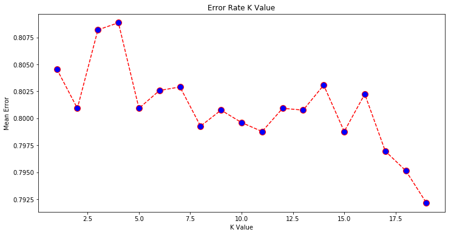

```python
index_null = data.loc[(data["CSat"].isnull())].index
data_null  = data.iloc[index_null]
data_full  = data.drop(data.index[index_null])

X = data_full[['CLIENT_ID','i.CLIENT_SIZE','i.INDUSTRY','i.STATE','i.PRODUCT','NUM_LICENSE','PRICE_PER_LICENSE']]
y = data_full['CSat']

from sklearn.model_selection import train_test_split
X_train, X_test, y_train, y_test = train_test_split(X, y, test_size=0.30)

from sklearn.preprocessing import StandardScaler
scaler = StandardScaler()
scaler.fit(X_train)
X_train = scaler.transform(X_train)
X_test = scaler.transform(X_test)

from sklearn.neighbors import KNeighborsClassifier as KNN
error = []
# Calculating error for K values between 1 and 20
for i in range(1, 20):
    knn = KNN(n_neighbors=i)
    knn.fit(X_train, y_train)
    pred_i = knn.predict(X_test)
    error.append(np.mean(pred_i != y_test))
plt.figure(figsize=(12, 6))
plt.plot(range(1, 20), error, color='red', linestyle='dashed', marker='o',
         markerfacecolor='blue', markersize=10)
plt.title('Error Rate K Value')
plt.xlabel('K Value')
plt.ylabel('Mean Error')
```

Choose optimal K=19.

```python
classifier = KNN(n_neighbors=19)
classifier.fit(X_train, y_train)
y_pred = classifier.predict(X_test)

from sklearn.metrics import classification_report, confusion_matrix
print(confusion_matrix(y_test, y_pred))
print(classification_report(y_test, y_pred))
```

```
[[  0   4   4   2   4   2   0   3   0   0]
 [  0  45  47  36  27  31  24  21   2   0]
 [  0  54  63  53  44  46  41  35   7   0]
 [  1  46  60  71  83  59  60  75  20   2]
 [  0  38  40  81 179 159 144 130   9   2]
 [  0  51  53  63 181 210 205 197  26   6]
 [  0  56  66  76 172 217 314 266  54  17]
 [  0  50  45  92 191 201 291 277  58  17]
 [  0   5  18  27  52  88 100 131  80  21]
 [  0   0   3  13  12  23  32  75  44  18]]
             precision    recall  f1-score   support

        1.0       0.00      0.00      0.00        19
        2.0       0.13      0.19      0.15       233
        3.0       0.16      0.18      0.17       343
        4.0       0.14      0.15      0.14       477
        5.0       0.19      0.23      0.21       782
        6.0       0.20      0.21      0.21       992
        7.0       0.26      0.25      0.26      1238
        8.0       0.23      0.23      0.23      1222
        9.0       0.27      0.15      0.19       522
       10.0       0.22      0.08      0.12       220

avg / total       0.21      0.21      0.21      6048
```

```python
X_null = data_null[['CLIENT_ID','i.CLIENT_SIZE','i.INDUSTRY','i.STATE','i.PRODUCT','NUM_LICENSE','PRICE_PER_LICENSE']]
y_null = classifier.predict(X_null)

data.loc[(data["CSat"].isnull()), "CSat"] = y_null
```

```python
print('Check if the ratings are integers')
y_null
```

```
Check if the ratings are integers
```

```
array([6., 6., 6., ..., 6., 6., 6.])
```

```python
data.isnull().sum()
```

```
DATE                 0
CLIENT_ID            0
CLIENT_SIZE          0
INDUSTRY             0
STATE                0
PRODUCT              0
NUM_LICENSE          0
PRICE_PER_LICENSE    0
CSat                 0
i.CLIENT_SIZE        0
i.INDUSTRY           0
i.STATE              0
i.PRODUCT            0
dtype: int64
```

Now we have predicted the missing value by KNN model, retruning a full dataset without missing value. That is good start for the following data analysis.

## Product v.s. Industry

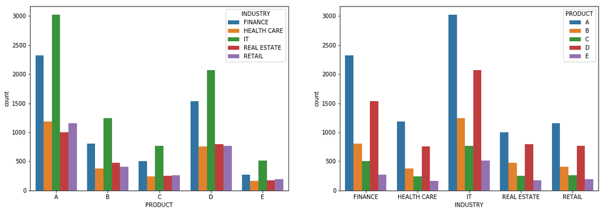

```python
df = data.sort_values(by=['PRODUCT', 'INDUSTRY'])

fig, ax = plt.subplots(figsize=(18,6))
plt.subplot(121)
sns.countplot(x='PRODUCT', hue='INDUSTRY', data=df)
plt.subplot(122)
sns.countplot(x='INDUSTRY', hue='PRODUCT', data=df)
plt.show()
```

The sale pattern is similar for each product in each industry. Product A and D are more popular; IT and Finance industry is the major clients.

## Sale Distribution over Product Price

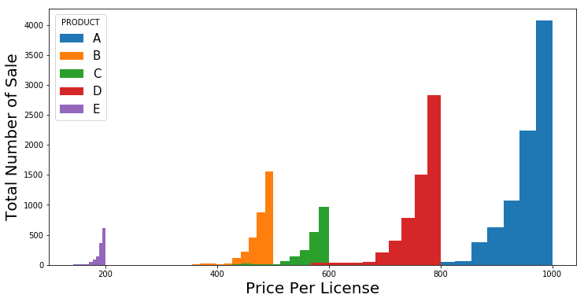

```python
plt.subplots(figsize=(12,6))

for product in ['A', 'B', 'C', 'D', 'E']:
    plt.hist(data[data["PRODUCT"] == product].PRICE_PER_LICENSE)

plt.xlabel('Price Per License', fontsize=20)
plt.ylabel('Total Number of Sale', fontsize=20)
plt.legend(["A", "B", "C", "D", "E"],title='PRODUCT',loc=2, prop={'size': 15})
plt.show()
```

Product A is sold at the highest price, followed by product D, and product E is the cheapest one.  
And most product is sold at it higher price.

# Question_1: Which product has had the highest revenue growth rate?

## Target variable: $REVENUE = UnitPrice* NumberSale$

```python
data["REVENUE"] = data["PRICE_PER_LICENSE"] * data["NUM_LICENSE"]
```

## set datetime (Y/Q/M)

```python
data['Year'] = pd.to_datetime(data.DATE).dt.to_period('Y')
data['Quarter'] = pd.to_datetime(data.DATE).dt.to_period('Q')
data['Month'] = pd.to_datetime(data.DATE).dt.to_period('M')
data.head()
```

|  | DATE | CLIENT_ID | CLIENT_SIZE | INDUSTRY | STATE | PRODUCT | NUM_LICENSE | PRICE_PER_LICENSE | CSat | i.CLIENT_SIZE | i.INDUSTRY | i.STATE | i.PRODUCT | REVENUE | Year | Quarter | Month |
| --- | --- | --- | --- | --- | --- | --- | --- | --- | --- | --- | --- | --- | --- | --- | --- | --- | --- |
| 0 | 1/2/14 | 9761603 | 500+ | IT | NJ | A | 26 | 770.0 | 6.0 | 3 | 2 | 11 | 0 | 20020.0 | 2014 | 2014Q1 | 2014-01 |
| 1 | 1/2/14 | 4856499 | 500+ | HEALTH CARE | TX | A | 15 | 930.0 | 7.0 | 3 | 1 | 14 | 0 | 13950.0 | 2014 | 2014Q1 | 2014-01 |
| 2 | 1/2/14 | 5855785 | 0-19 | IT | MN | A | 1 | 980.0 | 5.0 | 0 | 2 | 9 | 0 | 980.0 | 2014 | 2014Q1 | 2014-01 |
| 3 | 1/2/14 | 4095393 | 20-99 | IT | NJ | B | 4 | 500.0 | 9.0 | 2 | 2 | 11 | 1 | 2000.0 | 2014 | 2014Q1 | 2014-01 |
| 4 | 1/2/14 | 8152678 | 0-19 | IT | PA | D | 3 | 768.0 | 6.0 | 0 | 2 | 13 | 3 | 2304.0 | 2014 | 2014Q1 | 2014-01 |

## Plot the Revenue over Month, Quarter, Year

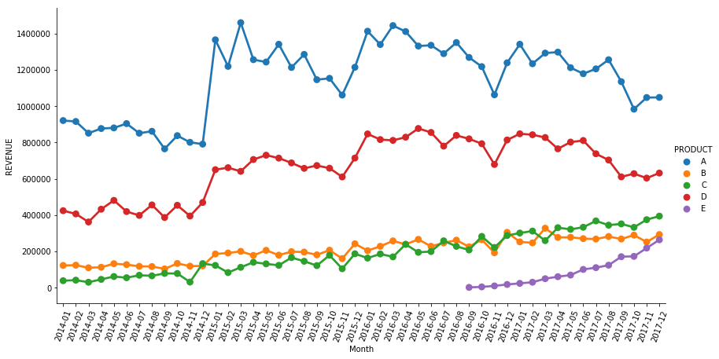

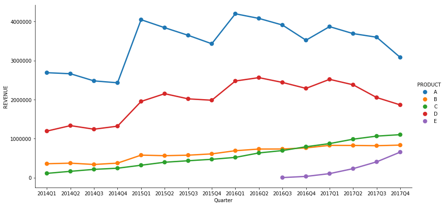

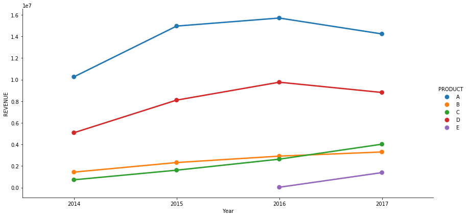

```python
REVENUE_Per_Month = pd.DataFrame(data.groupby(['PRODUCT', 'Month']).REVENUE.sum()).reset_index()
g = sns.catplot(x = 'Month', y = 'REVENUE', hue = 'PRODUCT', kind="point", data = REVENUE_Per_Month, height=6, aspect=12/6)
g.set_xticklabels(rotation = 70)

REVENUE_Per_Quarter = pd.DataFrame(data.groupby(['PRODUCT', 'Quarter']).REVENUE.sum()).reset_index()
sns.catplot(x = 'Quarter', y = 'REVENUE', hue = 'PRODUCT', kind="point", data = REVENUE_Per_Quarter, height=6, aspect=12/6)

REVENUE_Per_Year = pd.DataFrame(data.groupby(['PRODUCT', 'Year']).REVENUE.sum()).reset_index()
sns.catplot(x = 'Year', y = 'REVENUE', hue = 'PRODUCT', kind="point", data = REVENUE_Per_Year, height=6, aspect=12/6)

plt.show()
```

## Calculate Growth Rate (yearly )

We calculate the **annual growth rate** by two methods:

1) Take average over 4 years:

```python
Growth_Rate = []

for product in ['A','B','C','D']:
    REVENUE = REVENUE_Per_Year[REVENUE_Per_Year["PRODUCT"] == product]["REVENUE"].tolist()
    for year in [0,1,2]:
        Growth = (REVENUE[year+1] - REVENUE[year]) * 100 / REVENUE[year]
        Growth_Rate.append(Growth)


REVENUE = REVENUE_Per_Year[REVENUE_Per_Year["PRODUCT"] == "E"]["REVENUE"].tolist()
Growth_Rate.append(np.nan)
Growth_Rate.append(np.nan)
Growth_Rate.append((REVENUE[1] - REVENUE[0]) *100 / REVENUE[0])

Growth_Rate_A = Growth_Rate[0:3]
Growth_Rate_B = Growth_Rate[3:6]
Growth_Rate_C = Growth_Rate[6:9]
Growth_Rate_D = Growth_Rate[9:12]
Growth_Rate_E = Growth_Rate[12:15]

d = {'A':Growth_Rate_A,'B':Growth_Rate_B,'C':Growth_Rate_C,'D':Growth_Rate_D,'E':Growth_Rate_E,}
GR1 = pd.DataFrame(d,columns=['A','B','C','D','E']).T
GR1.columns = ['2014-2015','2015-2016','2016-2017']
GR1['Average'] = GR1.mean(axis=1)
```

2) Fit a line:

```python
Growth_Rate = []

from sklearn.linear_model import LinearRegression

for product in ['A','B','C','D']:

    y = REVENUE_Per_Year[REVENUE_Per_Year['PRODUCT']==product].REVENUE
    y = np.log(list(y))
    X = np.array(range(0,len(y))).reshape(-1, 1)

    reg = LinearRegression().fit(X, y)
    reg.score(X, y)
    coff = reg.coef_[0]
    Growth_Rate.append(coff*100)

Growth_Rate.append(np.nan)
d = {'Line_Slope':Growth_Rate}
GR2 = pd.DataFrame(d,index=['A','B','C','D','E'],columns=['Line_Slope'])
```

Now Report the annually growth rate:

```python
Growth_Rate = pd.concat([GR1, GR2],axis=1)
print()
print()
print('\033[1m     Table. Annually Revenue Growth Rate (%)')
Growth_Rate
```

```
     Table. Annually Revenue Growth Rate (%)
```

|  | 2014-2015 | 2015-2016 | 2016-2017 | Average | Line_Slope |
| --- | --- | --- | --- | --- | --- |
| A | 45.868065 | 4.973914 | -9.366838 | 13.825047 | 10.317138 |
| B | 61.789365 | 25.617191 | 13.241311 | 33.549289 | 27.287035 |
| C | 123.053564 | 63.332589 | 52.606497 | 79.664217 | 56.372762 |
| D | 59.411168 | 20.475168 | -9.740110 | 23.382075 | 18.366128 |
| E | NaN | NaN | 4210.731689 | 4210.731689 | NaN |

**Answer**:

About the revenue growth rate:

> Product C had the highest revenue growth rate over the last 4 years.  
> Product E lauched for only one year, but it grew fastest in last year.

# Question_2: Find major contributing factors to revenue growth of product E

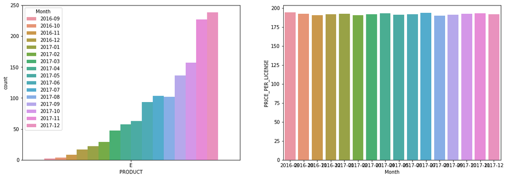

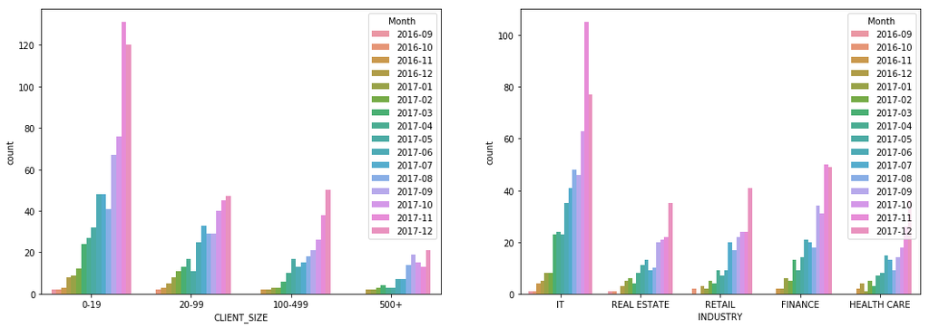

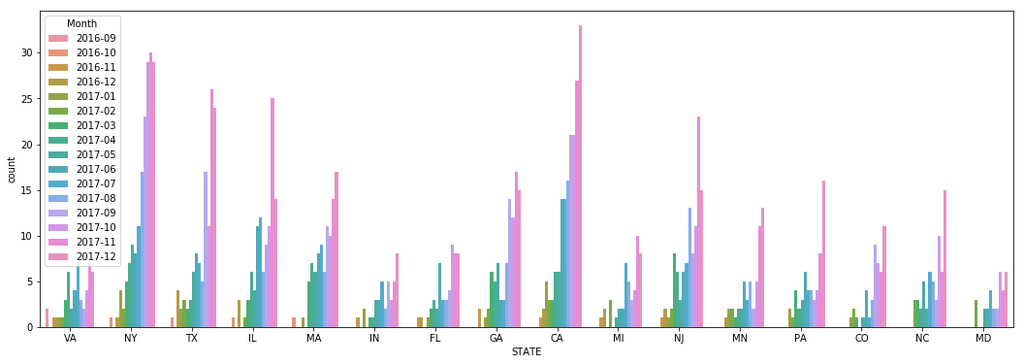

```python
Product_E = data[(data['PRODUCT'] == 'E')]
mean_price_E = pd.DataFrame(Product_E.groupby('Month').PRICE_PER_LICENSE.mean()).reset_index()

fig, ax = plt.subplots(figsize=(18,6))
plt.subplot(121)
sns.countplot(x='PRODUCT', hue='Month', data=Product_E)
plt.subplot(122)
sns.barplot(x='Month', y='PRICE_PER_LICENSE', data=mean_price_E)

fig, ax = plt.subplots(figsize=(18,6))
plt.subplot(121)
sns.countplot(x='CLIENT_SIZE', hue='Month', data=Product_E)
plt.subplot(122)
sns.countplot(x='INDUSTRY', hue='Month', data=Product_E)

fig, ax = plt.subplots(figsize=(18,6))
sns.countplot(x='STATE', hue='Month', data=Product_E)

plt.show()
```

**Answer**:

The dramatical increase in number of sale contributes to the fast revenue growth of product E, since the unit price remain constant over a year. We found same growth trend in all clients' size, industry sector, and location. The major contributing factor are remarkable increase of sale in clients with small-size in IT industry.

# Question_3: How to grow overall revenue?

## Revenue Distribution

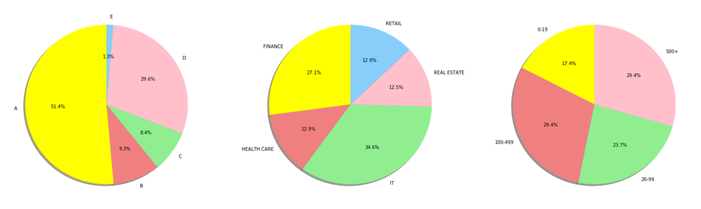

```python
# Pie chart
def Pie_Chart(group):
    sizes = data.groupby([group]).REVENUE.sum()
    labels = sizes.index.tolist()
    colors = ['yellow','lightcoral','lightgreen','pink','lightskyblue']
    plt.pie(sizes, labels=labels, colors=colors,autopct='%1.1f%%', shadow=True, startangle=90)
    ax.axis('equal')

fig, ax = plt.subplots(figsize=(27,8))
plt.subplot(131)
Pie_Chart('PRODUCT')
plt.subplot(132)
Pie_Chart('INDUSTRY')
plt.subplot(133)
Pie_Chart('CLIENT_SIZE')
plt.show()
```

These three Pie charts above show that:

> Product A and D, IT and Finance industry, and clients with 100+ employees make larger contribution to total revenue.

## Correlation matrix

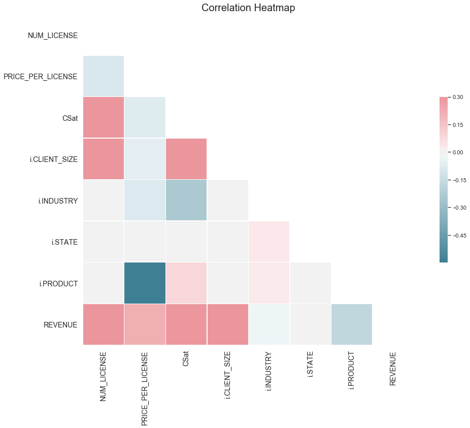

```python
# Compute the correlations between features except for the DATE and CLIENT_ID
correlation = data.drop(['DATE', 'CLIENT_ID'], axis=1).corr()

sns.set(style= 'white')

mask = np.zeros_like(correlation, dtype=np.bool)
mask[np.triu_indices_from(mask)] = True

# Set up the matplotlib figure
f, ax = plt.subplots(figsize=(18, 12))

# Generate a custom diverging colormap
cmap = sns.diverging_palette(220, 10, as_cmap=True)

# Draw the heatmap with the mask and correct aspect ratio
ax = sns.heatmap(correlation, mask=mask, cmap=cmap, vmax=.3, center=0,
                 square=True, linewidths=.5, cbar_kws={"shrink": .5})
ax.set_title("Correlation Heatmap", fontsize=20)
ax.set_xticklabels(ax.get_xticklabels(), rotation = 90, fontsize = 14)
ax.set_yticklabels(ax.get_yticklabels(), fontsize = 14)
plt.show()
```

From this correlation matrix, we notice that:

> (1) Revenue per order is positively related to license unit price and number of license sold.  
> (2) A client with more employees needs more copies of software licenses, so as increase the revenue.  
> (3) Clients would like to choose product with high rating, thus customer satisfaction score, client size and revenue are cross-correlated.  
> (4) Price of products has significant difference.

## Multivariable Linear Regression

```python
# Create a dataframe of monthly overall revenue with count of other feathers

tmp0 = pd.DataFrame(data.groupby(['Month']).REVENUE.sum()).reset_index()
tmp1 = pd.DataFrame(pd.crosstab(data['Month'], data['CLIENT_SIZE'])).reset_index()
tmp2 = pd.DataFrame(pd.crosstab(data['Month'], data['INDUSTRY'])).reset_index()
tmp3 = pd.DataFrame(pd.crosstab(data['Month'], data['PRODUCT'])).reset_index()
tmp4 = pd.DataFrame(data.groupby(['Month']).CSat.mean()).reset_index()

tmp = [tmp0, tmp1, tmp2, tmp3, tmp4]

result = pd.concat(tmp, axis=1)
result = result.T.drop_duplicates().T

order = [0,1,2,4,3] + list(range(5,17))
col = result.columns

result = result[col[order]]
result.head()
```

|  | Month | REVENUE | 0-19 | 20-99 | 100-499 | 500+ | FINANCE | HEALTH CARE | IT | REAL ESTATE | RETAIL | A | B | C | D | E | CSat |
| --- | --- | --- | --- | --- | --- | --- | --- | --- | --- | --- | --- | --- | --- | --- | --- | --- | --- |
| 0 | 2014-01 | 1.50521e+06 | 127 | 71 | 52 | 29 | 54 | 27 | 120 | 38 | 40 | 138 | 52 | 6 | 83 | 0 | 6.41219 |
| 1 | 2014-02 | 1.48714e+06 | 137 | 66 | 43 | 32 | 66 | 37 | 104 | 33 | 38 | 149 | 45 | 10 | 74 | 0 | 6.08993 |
| 2 | 2014-03 | 1.3523e+06 | 140 | 57 | 42 | 29 | 61 | 35 | 107 | 31 | 34 | 144 | 36 | 8 | 80 | 0 | 6.27239 |
| 3 | 2014-04 | 1.467e+06 | 127 | 69 | 44 | 32 | 74 | 31 | 98 | 33 | 36 | 135 | 46 | 13 | 78 | 0 | 6.37868 |
| 4 | 2014-05 | 1.55442e+06 | 140 | 72 | 59 | 24 | 76 | 31 | 110 | 31 | 47 | 154 | 48 | 11 | 82 | 0 | 6.06441 |

```python
import statsmodels.api as sm

result = result[result.columns].apply(pd.to_numeric, errors='coerce', axis=1)
y = result['REVENUE']
X = result.drop(['Month', 'REVENUE'], axis=1)

LM = sm.OLS(y, X)
LM_results = LM.fit()

print (LM_results.summary())
```

```
                            OLS Regression Results
==============================================================================
Dep. Variable:                REVENUE   R-squared:                       1.000
Model:                            OLS   Adj. R-squared:                  1.000
Method:                 Least Squares   F-statistic:                     9855.
Date:                Fri, 16 Nov 2018   Prob (F-statistic):           2.59e-58
Time:                        08:06:42   Log-Likelihood:                -574.05
No. Observations:                  48   AIC:                             1174.
Df Residuals:                      35   BIC:                             1198.
Df Model:                          13
Covariance Type:            nonrobust
===============================================================================
                  coef    std err          t      P>|t|      [0.025      0.975]
-------------------------------------------------------------------------------
0-19        -1951.6156    537.279     -3.632      0.001   -3042.349    -860.882
20-99       -1169.8949    721.322     -1.622      0.114   -2634.256     294.466
100-499      2880.7153    691.828      4.164      0.000    1476.231    4285.200
500+         9471.7672   1126.347      8.409      0.000    7185.161    1.18e+04
FINANCE      2769.2927    755.308      3.666      0.001    1235.935    4302.650
HEALTH CARE   -68.6889    717.629     -0.096      0.924   -1525.553    1388.175
IT           1044.6734    599.874      1.741      0.090    -173.135    2262.482
REAL ESTATE  1816.4389    970.256      1.872      0.070    -153.286    3786.163
RETAIL       3669.2560    928.038      3.954      0.000    1785.239    5553.273
A            2970.7916    535.105      5.552      0.000    1884.470    4057.113
B            1486.0204    858.656      1.731      0.092    -257.145    3229.186
C            1136.2228    813.126      1.397      0.171    -514.510    2786.955
D            4416.0206    792.546      5.572      0.000    2807.066    6024.975
E            -778.0833    351.757     -2.212      0.034   -1492.188     -63.978
CSat         7354.4261   8864.626      0.830      0.412   -1.06e+04    2.54e+04
==============================================================================
Omnibus:                        2.825   Durbin-Watson:                   2.016
Prob(Omnibus):                  0.243   Jarque-Bera (JB):                1.933
Skew:                          -0.292   Prob(JB):                        0.380
Kurtosis:                       2.209   Cond. No.                     7.43e+16
==============================================================================

Warnings:
[1] Standard Errors assume that the covariance matrix of the errors is correctly specified.
[2] The smallest eigenvalue is 1.5e-27. This might indicate that there are
strong multicollinearity problems or that the design matrix is singular.
```

# Conclusions:

From the regression results, we recommond that:

> (1) Introduce the products to large-size clients (employee>100).  
> (2) Develop more client in Finance and Retail industry.  
> (3) Boost the sale amount of product A and D, those are the major source of total revenue.

## [The End]

### Yuan Wang, Nov-15-2018